# # Machine Learing Assignment

Author: sohkura

## Introduction

The goal of this project is to predict the manner in which people did the exercise using the data from this source: http://groupware.les.inf.puc-rio.br/har for the Cousera Machine Learing assighment. It is greatly apprecaited that it have been very generous in allowing the data to be used for this kind of assignment.

## Data Load, Initial Analysis and Clean-up

1. Load the training and testing data from the website.
2. Check the data structure and observe some data. Noticed there are many NAs and “” in the training data set. Some of the columns are defined as factor variables.

```r
library(knitr)
library(caret)
```

3. Preprocess training data by converting those factore variables to numeric except “classe” variable.
4. Identify those columns whose data are NA and “”.
5. Remove those columns mostly NA from the training data. There are **160** columns in the original training data set. After removing those colunms that have mostly NA, “” and house keeping data such as X, user name, timestamps, and windows, the number of columns becomes **53**.

## Exploratory Analysis

The exploratory analysis was conducted against the training data. Based on the initial analysis and observation of the data, pick the following columns that seems to summarize the total activities and plot the relationships among them:

- total_accel_belt
- total_accel_arm
- total_accel_dumbbell
- total_accel_forearm

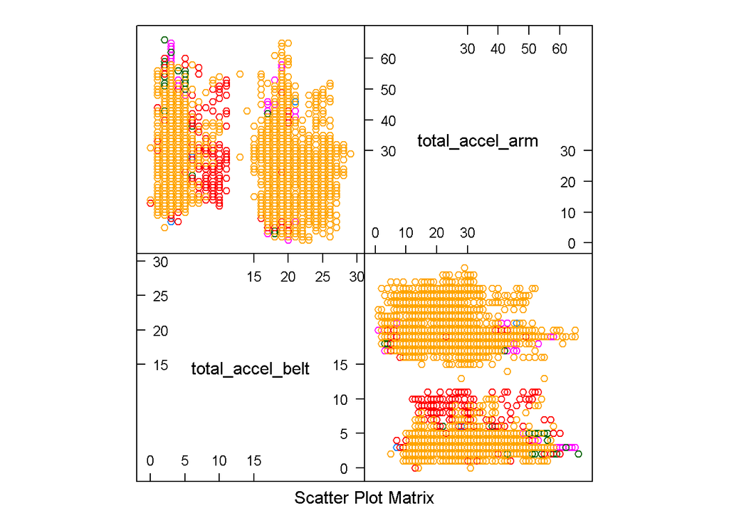

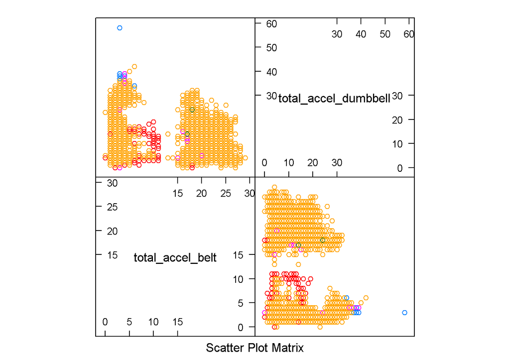

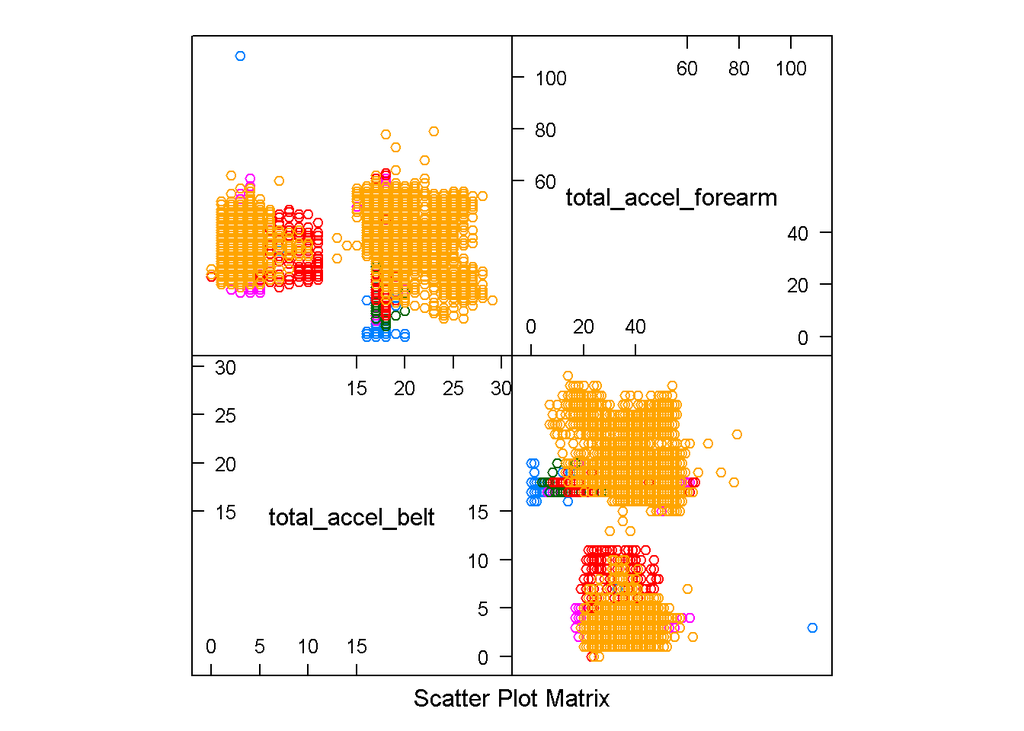

The graph shows the clear separation of the training data and it is grouped for each pair of **total_accel_belt** vs **total_accel_arm** or **total_accel_dumbbell** or **total_accel_forearm** respectivly.

## Create training and validation data partitioned from the trainng data set

The training data from the original data set is partitioned into **training* data and** validation** data that will be used for the model training and validation.

```r
inTrain <- createDataPartition(y=training.b$classe, p=0.7, list=FALSE)
training <- training.b[inTrain,]
validation <- training.b[-inTrain,]
dim(training)
```

```
## [1] 13737    53
```

```r
dim(validation)
```

```
## [1] 5885   53
```

## How to build the model, model Choice and Cross Validations

Two prediction models were executed and compared:

- Random Forest
- Recursive Partitioning and Regression Trees

The prediction models were performed using **train** function from the **caret** package. The **trainControl** was used to specify the **cross validation** with the number of resampling for fold.

```r
modFit <- train(classe ~ ., data = training, method = "rf",
                trControl = trainControl(method = "cv", number = 4))
modFit
```

```
## Random Forest
##
## 13737 samples
##    52 predictor
##     5 classes: 'A', 'B', 'C', 'D', 'E'
##
## No pre-processing
## Resampling: Cross-Validated (4 fold)
## Summary of sample sizes: 10303, 10303, 10302, 10303
## Resampling results across tuning parameters:
##
##   mtry  Accuracy   Kappa      Accuracy SD  Kappa SD
##    2    0.9898814  0.9871986  0.001243734  0.001575009
##   27    0.9898815  0.9871989  0.002246333  0.002842666
##   52    0.9823107  0.9776208  0.004147061  0.005246582
##
## Accuracy was used to select the optimal model using  the largest value.
## The final value used for the model was mtry = 27.
```

```r
modFit2 <- train(classe ~ ., data = training, method = "rpart",
                trControl = trainControl(method = "cv", number = 4))
modFit2
```

```
## CART
##
## 13737 samples
##    52 predictor
##     5 classes: 'A', 'B', 'C', 'D', 'E'
##
## No pre-processing
## Resampling: Cross-Validated (4 fold)
## Summary of sample sizes: 10302, 10302, 10304, 10303
## Resampling results across tuning parameters:
##
##   cp          Accuracy   Kappa       Accuracy SD  Kappa SD
##   0.03641542  0.5050602  0.35378064  0.01039000   0.01411405
##   0.05916658  0.4290553  0.23043254  0.07441055   0.12422520
##   0.11545112  0.3232902  0.05930541  0.04500642   0.06849289
##
## Accuracy was used to select the optimal model using  the largest value.
## The final value used for the model was cp = 0.03641542.
```

The **Recursive Partitioning and Regression Trees** was performed. The accuracy of this model is not as accurate as that of the **random forest**. For this reason, **random forest** was chosen as the final prediction model.

```r
modFit$finalModel
```

```
##
## Call:
##  randomForest(x = x, y = y, mtry = param$mtry)
##                Type of random forest: classification
##                      Number of trees: 500
## No. of variables tried at each split: 27
##
##         OOB estimate of  error rate: 0.65%
## Confusion matrix:
##      A    B    C    D    E class.error
## A 3901    3    1    0    1 0.001280082
## B   17 2628   11    2    0 0.011286682
## C    0   13 2379    4    0 0.007095159
## D    1    0   23 2227    1 0.011101243
## E    0    1    5    6 2513 0.004752475
```

The confusio matrix of the final model of the **random forest** with the number = 4 is shown above. The classification error rate is about 1% or less for each classification, A, B, C, D, E.

```r
var_importance <- varImp(modFit, scale = FALSE)
var_importance
```

```
## rf variable importance
##
##   only 20 most important variables shown (out of 52)
##
##                      Overall
## roll_belt             1429.2
## pitch_forearm          849.9
## yaw_belt               774.4
## pitch_belt             641.1
## magnet_dumbbell_z      623.4
## magnet_dumbbell_y      611.9
## roll_forearm           610.5
## accel_dumbbell_y       333.9
## magnet_dumbbell_x      269.2
## roll_dumbbell          263.5
## accel_forearm_x        261.7
## magnet_belt_z          227.1
## accel_dumbbell_z       209.2
## total_accel_dumbbell   208.9
## magnet_forearm_z       202.5
## accel_belt_z           197.7
## magnet_belt_y          196.3
## magnet_belt_x          174.0
## yaw_arm                162.4
## gyros_belt_z           162.3
```

The variable importance is calcuated using caret package to see which variables are more important. The further analysis is necessary, however this is skipped in this assignment.

## Expected out of sample errors with cross validaion

The model obtained from the training data set is validated against the validation data set created in the previous step.

```r
pred <- predict(modFit, validation)
predRight <- pred == validation$classe
error.rate <- (1 - (sum(predRight)/dim(validation)[1]))
```

The out of sample error of the model is calculated againt the validation data set. The **out of sample error rate** is **0.005438** or **0.5 %**.

## 20 different test cases

The prediction model is applied to the test data that contain 20 test cases.

```r
test.predict <- predict(modFit, testing)
test.predict
```

```
##  [1] B A B A A E D B A A B C B A E E A B B B
## Levels: A B C D E
```

The prediction results for the 20 test cases are ouput to the corresponding files.

```r
pml_write_files = function(x){
  n = length(x)
  for(i in 1:n){
    filename = paste0("problem_id_",i,".txt")
    write.table(x[i],file=filename,quote=FALSE,row.names=FALSE,col.names=FALSE)
  }
}
test.out <- c(as.character(test.predict))
pml_write_files(test.out)
```

The End.